# Assignment#4 - ML regression and BL regression models

Douglas Barley, Ethan Haley, Isabel Magnus, John Mazon, Vinayak Kamath, Arushi Arora

11/07/2021

DATA 621 – Business Analytics and Data Mining

# Overview

In this homework assignment, you will explore, analyze and model a data set containing approximately 8000 records representing a customer at an auto insurance company. Each record has two response variables. The first response variable, TARGET_FLAG, is a 1 or a 0. A “1” means that the person was in a car crash. A zero means that the person was not in a car crash. The second response variable is TARGET_AMT. This value is zero if the person did not crash their car. But if they did crash their car, this number will be a value greater than zero.

Your objective is to build multiple linear regression and binary logistic regression models on the training data to predict the probability that a person will crash their car and also the amount of money it will cost if the person does crash their car. You can only use the variables given to you (or variables that you derive from the variables provided).

- **INDEX**: Identification Variable (do not use)
- **TARGET_FLAG**: Was Car in a crash? 1=YES 0=NO None
- **TARGET_AMT**: If car was in a crash, what was the cost None
- **AGE**: Age of Driver Very young people tend to be risky. Maybe very old people also.
- **BLUEBOOK**: Value of Vehicle Unknown effect on probability of collision, but probably effect the payout if there is a crash
- **CAR_AGE**: Vehicle Age Unknown effect on probability of collision, but probably effect the payout if there is a crash
- **CAR_TYPE**: Type of Car Unknown effect on probability of collision, but probably effect the payout if there is a crash
- **CAR_USE**: Vehicle Use Commercial vehicles are driven more, so might increase probability of collision
- **CLM_FREQ**: # Claims (Past 5 Years) The more claims you filed in the past, the more you are likely to file in the future
- **EDUCATION**: Max Education Level Unknown effect, but in theory more educated people tend to drive more safely
- **HOMEKIDS**: # Children at Home Unknown effect
- **HOME_VAL**: Home Value In theory, home owners tend to drive more responsibly
- **INCOME**: Income In theory, rich people tend to get into fewer crashes
- **JOB**: Job Category In theory, white collar jobs tend to be safer
- **KIDSDRIV**: # Driving Children When teenagers drive your car, you are more likely to get into crashes
- **MSTATUS**: Marital Status In theory, married people drive more safely
- **MVR_PTS**: Motor Vehicle Record Points If you get lots of traffic tickets, you tend to get into more crashes
- **OLDCLAIM**: Total Claims (Past 5 Years) If your total payout over the past five years was high, this suggests future payouts will be high
- **PARENT1**: Single Parent Unknown effect
- **RED_CAR**: A Red Car Urban legend says that red cars (especially red sports cars) are more risky. Is that true?
- **REVOKED**: License Revoked (Past 7 Years) If your license was revoked in the past 7 years, you probably are a more risky driver.
- **SEX**: Gender Urban legend says that women have less crashes then men. Is that true?
- **TIF**: Time in Force People who have been customers for a long time are usually more safe.
- **TRAVTIME**: Distance to Work Long drives to work usually suggest greater risk
- **URBANICITY**: Home/Work Area Unknown
- **YOJ**: Years on Job People who stay at a job for a long time are usually more safe

## 1. Data Exploration

Describe the size and the variables in the insurance training data set. Consider that too much detail will cause a manager to lose interest while too little detail will make the manager consider that you aren’t doing your job. Some suggestions are given below. Please do NOT treat this as a check list of things to do to complete the assignment. You should have your own thoughts on what to tell the boss. These are just ideas. a. Mean / Standard Deviation / Median b. Bar Chart or Box Plot of the data c. Is the data correlated to the target variable (or to other variables?) d. Are any of the variables missing and need to be imputed “fixed”?

## 2. Data Preparation

Describe how you have transformed the data by changing the original variables or creating new variables. If you did transform the data or create new variables, discuss why you did this. Here are some possible transformations.

1. Fix missing values (maybe with a Mean or Median value)
2. Create flags to suggest if a variable was missing
3. Transform data by putting it into buckets
4. Mathematical transforms such as log or square root (or use Box-Cox)
5. Combine variables (such as ratios or adding or multiplying) to create new variables

### Load datasets

```r
ins_train_df <- read.csv("https://raw.githubusercontent.com/johnm1990/msds-621/main/insurance_training_data.csv")
ins_eval_df <- read.csv("https://raw.githubusercontent.com/johnm1990/msds-621/main/insurance-evaluation-data.csv")
```

### inspect values

```r
summary(ins_train_df)
```

```
##      INDEX        TARGET_FLAG       TARGET_AMT        KIDSDRIV
##  Min.   :    1   Min.   :0.0000   Min.   :     0   Min.   :0.0000
##  1st Qu.: 2559   1st Qu.:0.0000   1st Qu.:     0   1st Qu.:0.0000
##  Median : 5133   Median :0.0000   Median :     0   Median :0.0000
##  Mean   : 5152   Mean   :0.2638   Mean   :  1504   Mean   :0.1711
##  3rd Qu.: 7745   3rd Qu.:1.0000   3rd Qu.:  1036   3rd Qu.:0.0000
##  Max.   :10302   Max.   :1.0000   Max.   :107586   Max.   :4.0000
##
##       AGE           HOMEKIDS           YOJ            INCOME     PARENT1
##  Min.   :16.00   Min.   :0.0000   Min.   : 0.0   $0      : 615   No :7084
##  1st Qu.:39.00   1st Qu.:0.0000   1st Qu.: 9.0           : 445   Yes:1077
##  Median :45.00   Median :0.0000   Median :11.0   $26,840 :   4
##  Mean   :44.79   Mean   :0.7212   Mean   :10.5   $48,509 :   4
##  3rd Qu.:51.00   3rd Qu.:1.0000   3rd Qu.:13.0   $61,790 :   4
##  Max.   :81.00   Max.   :5.0000   Max.   :23.0   $107,375:   3
##  NA's   :6                        NA's   :454    (Other) :7086
##      HOME_VAL    MSTATUS      SEX               EDUCATION
##  $0      :2294   Yes :4894   M  :3786   <High School :1203
##          : 464   z_No:3267   z_F:4375   Bachelors    :2242
##  $111,129:   3                          Masters      :1658
##  $115,249:   3                          PhD          : 728
##  $123,109:   3                          z_High School:2330
##  $153,061:   3
##  (Other) :5391
##             JOB          TRAVTIME            CAR_USE        BLUEBOOK
##  z_Blue Collar:1825   Min.   :  5.00   Commercial:3029   $1,500 : 157
##  Clerical     :1271   1st Qu.: 22.00   Private   :5132   $6,000 :  34
##  Professional :1117   Median : 33.00                     $5,800 :  33
##  Manager      : 988   Mean   : 33.49                     $6,200 :  33
##  Lawyer       : 835   3rd Qu.: 44.00                     $6,400 :  31
##  Student      : 712   Max.   :142.00                     $5,900 :  30
##  (Other)      :1413                                      (Other):7843
##       TIF                CAR_TYPE    RED_CAR       OLDCLAIM       CLM_FREQ
##  Min.   : 1.000   Minivan    :2145   no :5783   $0     :5009   Min.   :0.0000
##  1st Qu.: 1.000   Panel Truck: 676   yes:2378   $1,310 :   4   1st Qu.:0.0000
##  Median : 4.000   Pickup     :1389              $1,391 :   4   Median :0.0000
##  Mean   : 5.351   Sports Car : 907              $4,263 :   4   Mean   :0.7986
##  3rd Qu.: 7.000   Van        : 750              $1,105 :   3   3rd Qu.:2.0000
##  Max.   :25.000   z_SUV      :2294              $1,332 :   3   Max.   :5.0000
##                                                 (Other):3134
##  REVOKED       MVR_PTS          CAR_AGE                       URBANICITY
##  No :7161   Min.   : 0.000   Min.   :-3.000   Highly Urban/ Urban  :6492
##  Yes:1000   1st Qu.: 0.000   1st Qu.: 1.000   z_Highly Rural/ Rural:1669
##             Median : 1.000   Median : 8.000
##             Mean   : 1.696   Mean   : 8.328
##             3rd Qu.: 3.000   3rd Qu.:12.000
##             Max.   :13.000   Max.   :28.000
##                              NA's   :510
```

```r
#before whole list of columns telling class, now showing measure

ins_train_df <- as.data.frame(lapply(ins_train_df, gsub, pattern='z_', replacement=''))
ins_eval_df <- as.data.frame(lapply(ins_eval_df, gsub, pattern='z_', replacement=''))
cols.num <- c("TARGET_FLAG",
"TARGET_AMT","AGE","YOJ","TRAVTIME","TIF","CLM_FREQ",
"MVR_PTS","CAR_AGE","KIDSDRIV","HOMEKIDS")

ins_train_df[cols.num] <- sapply(ins_train_df[cols.num],as.numeric)
ins_eval_df[cols.num] <- sapply(ins_eval_df[cols.num],as.numeric)

cols.fac <- c("EDUCATION", "SEX", "CAR_TYPE", "JOB", "CAR_USE", "URBANICITY")

ins_train_df[cols.fac] <- sapply(ins_train_df[cols.fac],factor)
ins_eval_df[cols.fac] <- sapply(ins_eval_df[cols.fac],factor)


#do not need, the function already handled
#ins_train_df <- lapply(ins_train_df, gsub, pattern='$', replacement='')
#ins_eval_df <- lapply(ins_eval_df, gsub, pattern='$', replacement='')

#ins_train_df <- lapply(ins_train_df, gsub, pattern=',', replacement='')
#ins_eval_df <- lapply(ins_eval_df, gsub, pattern=',', replacement='')

ins_eval_df$SEX <- factor(ins_eval_df$SEX)
ins_train_df$SEX <- factor(ins_train_df$SEX)
ins_eval_df$JOB <- factor(ins_eval_df$JOB)
ins_train_df$JOB <- factor(ins_train_df$JOB)
ins_eval_df$CAR_USE <- factor(ins_eval_df$CAR_USE)
ins_train_df$CAR_USE <- factor(ins_train_df$CAR_USE)
ins_eval_df$CAR_TYPE <- factor(ins_eval_df$CAR_TYPE)
ins_train_df$CAR_TYPE <- factor(ins_train_df$CAR_TYPE)
ins_eval_df$URBANICITY <- factor(ins_eval_df$URBANICITY)
ins_train_df$URBANICITY <- factor(ins_train_df$URBANICITY)

ins_eval_df$EDUCATION <- factor(ins_eval_df$EDUCATION,
                                   levels = c("<High School", "High School",
                                               "Bachelors", "Masters", "PhD"),
                                    ordered = T)
ins_train_df$EDUCATION <- factor(ins_train_df$EDUCATION,
                                   levels = c("<High School", "High School",
                                               "Bachelors", "Masters", "PhD"),
                                    ordered = T)
```

#### Some columns should be numbers but aren’t

```r
#print first six values
head(ins_train_df$BLUEBOOK)
```

```
## [1] $14,230 $14,940 $4,010  $15,440 $18,000 $17,430
## 2789 Levels: $1,500 $1,520 $1,530 $1,540 $1,590 $1,620 $1,650 $1,670 ... $9,990
```

```r
typeof(ins_train_df$BLUEBOOK)
```

```
## [1] "integer"
```

```r
head(ins_train_df$INCOME)
```

```
## [1] $67,349  $91,449  $16,039           $114,986 $125,301
## 6613 Levels:  $0 $1,007 $1,022 $1,102 $1,114 $1,133 $1,158 $1,201 ... $997
```

```r
typeof(ins_train_df$INCOME)
```

```
## [1] "integer"
```

```r
head(ins_train_df$HOME_VAL)
```

```
## [1] $0       $257,252 $124,191 $306,251 $243,925 $0
## 5107 Levels:  $0 $100,093 $100,123 $100,226 $100,327 $100,519 ... $99,968
```

```r
typeof(ins_train_df$HOME_VAL)
```

```
## [1] "integer"
```

```r
head(ins_train_df$OLDCLAIM)
```

```
## [1] $4,461  $0      $38,690 $0      $19,217 $0
## 2857 Levels: $0 $1,000 $1,008 $1,011 $1,012 $1,015 $1,019 $1,020 ... $999
```

```r
typeof(ins_train_df$OLDCLAIM)
```

```
## [1] "integer"
```

#### convert strings to integers, filling blanks as 0

#need to check for decimals, convert to integer.No decimals. #these four variables need to add them to ins_train_numeric

```r
head(ins_train_df$INCOME)
```

```
## [1] $67,349  $91,449  $16,039           $114,986 $125,301
## 6613 Levels:  $0 $1,007 $1,022 $1,102 $1,114 $1,133 $1,158 $1,201 ... $997
```

```r
#change it to as.numeric from original (as.integer) ***overwrites existing character type
dollars <- function(n){
  as.numeric(paste0('0', str_remove_all(n, '[,$]')))  # add leading zero for blanks
}
dollars(ins_train_df$INCOME[1:11])
```

```
##  [1]  67349  91449  16039      0 114986 125301  18755 107961  62978 106952
## [11]  77100
```

```r
#converting to dollars of blue blook

ins_eval_df$BLUEBOOK = dollars(ins_eval_df$BLUEBOOK)
ins_train_df$BLUEBOOK = dollars(ins_train_df$BLUEBOOK)
ins_eval_df$HOME_VAL = dollars(ins_eval_df$HOME_VAL)
ins_train_df$HOME_VAL = dollars(ins_train_df$HOME_VAL)
ins_eval_df$INCOME = dollars(ins_eval_df$INCOME)
ins_train_df$INCOME = dollars(ins_train_df$INCOME)
ins_eval_df$OLDCLAIM = dollars(ins_eval_df$OLDCLAIM)
ins_train_df$OLDCLAIM = dollars(ins_train_df$OLDCLAIM)
```

#### Inspect more features

```r
#change to head
ins_train_df$PARENT1[1:11]
```

```
##  [1] No  No  No  No  No  Yes No  No  No  No  No
## Levels: No Yes
```

```r
ins_train_df$MSTATUS[1:11]
```

```
##  [1] No  No  Yes Yes Yes No  Yes Yes No  No  No
## Levels: No Yes
```

```r
ins_train_df$SEX[1:11]
```

```
##  [1] M M F M F F F M F M F
## Levels: F M
```

```r
ins_train_df$EDUCATION[1:11]
```

```
##  [1] PhD          High School  High School  <High School PhD
##  [6] Bachelors    <High School Bachelors    Bachelors    Bachelors
## [11] Masters
## Levels: <High School < High School < Bachelors < Masters < PhD
```

```r
ins_train_df$JOB[1:11]
```

```
##  [1] Professional Blue Collar  Clerical     Blue Collar  Doctor
##  [6] Blue Collar  Blue Collar  Blue Collar  Clerical     Professional
## [11] Lawyer
## 9 Levels:  Blue Collar Clerical Doctor Home Maker Lawyer ... Student
```

```r
ins_train_df$CAR_USE[1:11]
```

```
##  [1] Private    Commercial Private    Private    Private    Commercial
##  [7] Private    Commercial Private    Commercial Private
## Levels: Commercial Private
```

```r
ins_train_df$CAR_TYPE[1:11]
```

```
##  [1] Minivan    Minivan    SUV        Minivan    SUV        Sports Car
##  [7] SUV        Van        SUV        Van        Sports Car
## Levels: Minivan Panel Truck Pickup Sports Car SUV Van
```

```r
ins_train_df$REVOKED[1:11]
```

```
##  [1] No  No  No  No  Yes No  No  Yes No  No  No
## Levels: No Yes
```

```r
ins_train_df$URBANICITY[1:11]
```

```
##  [1] Highly Urban/ Urban Highly Urban/ Urban Highly Urban/ Urban
##  [4] Highly Urban/ Urban Highly Urban/ Urban Highly Urban/ Urban
##  [7] Highly Urban/ Urban Highly Urban/ Urban Highly Urban/ Urban
## [10] Highly Rural/ Rural Highly Urban/ Urban
## Levels: Highly Rural/ Rural Highly Urban/ Urban
```

```r
ins_train_df$RED_CAR[1:11]
```

```
##  [1] yes yes no  yes no  no  no  yes no  no  no
## Levels: no yes
```

```r
table(ins_train_df$URBANICITY)
```

```
##
## Highly Rural/ Rural Highly Urban/ Urban
##                1669                6492
```

#### Turn boolean strings into booleans

```r
#not necessary
#changes to logical type

table(ins_train_df$REVOKED)
```

```
##
##   No  Yes
## 7161 1000
```

```r
ins_train_df$REVOKED = tolower(ins_train_df$REVOKED)=='yes'
ins_eval_df$REVOKED = tolower(ins_eval_df$REVOKED)=='yes'
ins_train_df$PARENT1 = tolower(ins_train_df$PARENT1)=='yes'
ins_eval_df$PARENT1 = tolower(ins_eval_df$PARENT1)=='yes'
ins_train_df$RED_CAR = tolower(ins_train_df$RED_CAR)=='yes'
ins_eval_df$RED_CAR = tolower(ins_eval_df$RED_CAR)=='yes'
ins_train_df$MSTATUS = tolower(ins_train_df$MSTATUS)=='yes'
ins_eval_df$MSTATUS = tolower(ins_eval_df$MSTATUS)=='yes'
```

```r
summary(ins_train_df)
```

```
##      INDEX       TARGET_FLAG      TARGET_AMT        KIDSDRIV
##  1      :   1   Min.   :1.000   Min.   :   1.0   Min.   :1.000
##  100    :   1   1st Qu.:1.000   1st Qu.:   1.0   1st Qu.:1.000
##  1000   :   1   Median :1.000   Median :   1.0   Median :1.000
##  10001  :   1   Mean   :1.264   Mean   : 258.7   Mean   :1.171
##  10002  :   1   3rd Qu.:2.000   3rd Qu.: 111.0   3rd Qu.:1.000
##  10004  :   1   Max.   :2.000   Max.   :1949.0   Max.   :5.000
##  (Other):8155
##       AGE           HOMEKIDS          YOJ             INCOME
##  Min.   : 1.00   Min.   :1.000   Min.   : 1.000   Min.   :     0
##  1st Qu.:24.00   1st Qu.:1.000   1st Qu.: 4.000   1st Qu.: 23157
##  Median :30.00   Median :1.000   Median : 6.000   Median : 51116
##  Mean   :29.79   Mean   :1.721   Mean   : 7.993   Mean   : 58523
##  3rd Qu.:36.00   3rd Qu.:2.000   3rd Qu.: 8.000   3rd Qu.: 83304
##  Max.   :60.00   Max.   :6.000   Max.   :21.000   Max.   :367030
##  NA's   :6                       NA's   :454
##   PARENT1           HOME_VAL       MSTATUS        SEX             EDUCATION
##  Mode :logical   Min.   :     0   Mode :logical   F:4375   <High School:1203
##  FALSE:7084      1st Qu.:     0   FALSE:3267      M:3786   High School :2330
##  TRUE :1077      Median :151957   TRUE :4894               Bachelors   :2242
##                  Mean   :146062                            Masters     :1658
##                  3rd Qu.:233352                            PhD         : 728
##                  Max.   :885282
##
##            JOB          TRAVTIME           CAR_USE        BLUEBOOK
##  Blue Collar :1825   Min.   : 1.00   Commercial:3029   Min.   : 1500
##  Clerical    :1271   1st Qu.:22.00   Private   :5132   1st Qu.: 9280
##  Professional:1117   Median :33.00                     Median :14440
##  Manager     : 988   Mean   :34.19                     Mean   :15710
##  Lawyer      : 835   3rd Qu.:44.00                     3rd Qu.:20850
##  Student     : 712   Max.   :97.00                     Max.   :69740
##  (Other)     :1413
##       TIF               CAR_TYPE     RED_CAR           OLDCLAIM
##  Min.   : 1.00   Minivan    :2145   Mode :logical   Min.   :    0
##  1st Qu.: 1.00   Panel Truck: 676   FALSE:5783      1st Qu.:    0
##  Median : 9.00   Pickup     :1389   TRUE :2378      Median :    0
##  Mean   :10.54   Sports Car : 907                   Mean   : 4037
##  3rd Qu.:20.00   SUV        :2294                   3rd Qu.: 4636
##  Max.   :23.00   Van        : 750                   Max.   :57037
##
##     CLM_FREQ      REVOKED           MVR_PTS         CAR_AGE
##  Min.   :1.000   Mode :logical   Min.   : 1.00   Min.   : 1.00
##  1st Qu.:1.000   FALSE:7161      1st Qu.: 1.00   1st Qu.: 3.00
##  Median :1.000   TRUE :1000      Median : 2.00   Median : 8.00
##  Mean   :1.799                   Mean   : 3.87   Mean   :13.35
##  3rd Qu.:3.000                   3rd Qu.: 7.00   3rd Qu.:27.00
##  Max.   :6.000                   Max.   :13.00   Max.   :30.00
##                                                  NA's   :510
##                URBANICITY
##  Highly Rural/ Rural:1669
##  Highly Urban/ Urban:6492
##
##
##
##
##
```

```r
ins_train_df$INCOME <- as.numeric(ins_train_df$INCOME)
typeof(ins_train_df$INCOME)
```

```
## [1] "double"
```

```r
head(ins_train_df$INCOME)
```

```
## [1]  67349  91449  16039      0 114986 125301
```

```r
#x include all numeric column **leave until we see correlation
#summaries for mean

ins_train_numeric <- ins_train_df %>%
  dplyr::select(where(is.numeric))
#we will see what type of variable they are with str
str(ins_train_df)
```

```
## 'data.frame':    8161 obs. of  26 variables:
##  $ INDEX      : Factor w/ 8161 levels "1","100","1000",..: 1 1132 2898 3795 4666 5531 6390 334 430 508 ...
##  $ TARGET_FLAG: num  1 1 1 1 1 2 1 2 2 1 ...
##  $ TARGET_AMT : num  1 1 1 1 1 612 1 989 460 1 ...
##  $ KIDSDRIV   : num  1 1 1 1 1 1 1 2 1 1 ...
##  $ AGE        : num  45 28 20 36 35 19 39 22 19 35 ...
##  $ HOMEKIDS   : num  1 1 2 1 1 2 1 3 1 1 ...
##  $ YOJ        : num  4 4 3 7 NA 5 NA NA 3 19 ...
##  $ INCOME     : num  67349 91449 16039 0 114986 ...
##  $ PARENT1    : logi  FALSE FALSE FALSE FALSE FALSE TRUE ...
##  $ HOME_VAL   : num  0 257252 124191 306251 243925 ...
##  $ MSTATUS    : logi  FALSE FALSE TRUE TRUE TRUE FALSE ...
##  $ SEX        : Factor w/ 2 levels "F","M": 2 2 1 2 1 1 1 2 1 2 ...
##  $ EDUCATION  : Ord.factor w/ 5 levels "<High School"<..: 5 2 2 1 5 3 1 3 3 3 ...
##  $ JOB        : Factor w/ 9 levels "","Blue Collar",..: 8 2 3 2 4 2 2 2 3 8 ...
##  $ TRAVTIME   : num  10 19 47 29 33 43 30 41 31 45 ...
##  $ CAR_USE    : Factor w/ 2 levels "Commercial","Private": 2 1 2 2 2 1 2 1 2 1 ...
##  $ BLUEBOOK   : num  14230 14940 4010 15440 18000 ...
##  $ TIF        : num  3 1 18 21 1 1 1 1 1 21 ...
##  $ CAR_TYPE   : Factor w/ 6 levels "Minivan","Panel Truck",..: 1 1 5 1 5 4 5 6 5 6 ...
##  $ RED_CAR    : logi  TRUE TRUE FALSE TRUE FALSE FALSE ...
##  $ OLDCLAIM   : num  4461 0 38690 0 19217 ...
##  $ CLM_FREQ   : num  3 1 3 1 3 1 1 2 1 1 ...
##  $ REVOKED    : logi  FALSE FALSE FALSE FALSE TRUE FALSE ...
##  $ MVR_PTS    : num  7 1 7 1 7 1 1 3 1 2 ...
##  $ CAR_AGE    : num  12 3 4 27 11 28 3 28 3 11 ...
##  $ URBANICITY : Factor w/ 2 levels "Highly Rural/ Rural",..: 2 2 2 2 2 2 2 2 2 1 ...
```

```r
kable(sapply(ins_train_numeric, function(ins_train_numeric) c( "Stand dev" = sd(ins_train_numeric),
                         "Mean"= mean(ins_train_numeric,na.rm=TRUE),
                         "n" = length(ins_train_numeric),
                         "Median" = median(ins_train_numeric,na.rm = TRUE),
                         "CoeffofVariation" = sd(ins_train_numeric)/mean(ins_train_numeric,na.rm=TRUE),
                         "Minimum" = min(ins_train_numeric),
                         "Maximum" = max(ins_train_numeric),
                         "Upper Quantile" = quantile(ins_train_numeric,1,na.rm = TRUE),
                         "LowerQuartile" = quantile(ins_train_numeric,0,na.rm = TRUE)
                    )
)
)
```

|  | TARGET_FLAG | TARGET_AMT | KIDSDRIV | AGE | HOMEKIDS | YOJ | INCOME | HOME_VAL | TRAVTIME | BLUEBOOK | TIF | OLDCLAIM | CLM_FREQ | MVR_PTS | CAR_AGE |
| --- | --- | --- | --- | --- | --- | --- | --- | --- | --- | --- | --- | --- | --- | --- | --- |
| Stand dev | 0.4407276 | 516.095300 | 0.5115341 | NA | 1.1163233 | NA | 4.834551e+04 | 1.304267e+05 | 16.5963585 | 8.419734e+03 | 8.8261511 | 8777.139104 | 1.1584527 | 3.4096683 | NA |
| Mean | 1.2638157 | 258.742679 | 1.1710575 | 29.78774 | 1.7212351 | 7.992734 | 5.852294e+04 | 1.460622e+05 | 34.1910305 | 1.570990e+04 | 10.5359637 | 4037.076216 | 1.7985541 | 3.8703590 | 13.34544 |
| n | 8161.0000000 | 8161.000000 | 8161.0000000 | 8161.00000 | 8161.0000000 | 8161.000000 | 8.161000e+03 | 8.161000e+03 | 8161.0000000 | 8.161000e+03 | 8161.0000000 | 8161.000000 | 8161.0000000 | 8161.0000000 | 8161.00000 |
| Median | 1.0000000 | 1.000000 | 1.0000000 | 30.00000 | 1.0000000 | 6.000000 | 5.111600e+04 | 1.519570e+05 | 33.0000000 | 1.444000e+04 | 9.0000000 | 0.000000 | 1.0000000 | 2.0000000 | 8.00000 |
| CoeffofVariation | 0.3487277 | 1.994628 | 0.4368138 | NA | 0.6485594 | NA | 8.260951e-01 | 8.929533e-01 | 0.4854009 | 5.359509e-01 | 0.8377165 | 2.174133 | 0.6441022 | 0.8809695 | NA |
| Minimum | 1.0000000 | 1.000000 | 1.0000000 | NA | 1.0000000 | NA | 0.000000e+00 | 0.000000e+00 | 1.0000000 | 1.500000e+03 | 1.0000000 | 0.000000 | 1.0000000 | 1.0000000 | NA |
| Maximum | 2.0000000 | 1949.000000 | 5.0000000 | NA | 6.0000000 | NA | 3.670300e+05 | 8.852820e+05 | 97.0000000 | 6.974000e+04 | 23.0000000 | 57037.000000 | 6.0000000 | 13.0000000 | NA |
| Upper Quantile.100% | 2.0000000 | 1949.000000 | 5.0000000 | 60.00000 | 6.0000000 | 21.000000 | 3.670300e+05 | 8.852820e+05 | 97.0000000 | 6.974000e+04 | 23.0000000 | 57037.000000 | 6.0000000 | 13.0000000 | 30.00000 |
| LowerQuartile.0% | 1.0000000 | 1.000000 | 1.0000000 | 1.00000 | 1.0000000 | 1.000000 | 0.000000e+00 | 0.000000e+00 | 1.0000000 | 1.500000e+03 | 1.0000000 | 0.000000 | 1.0000000 | 1.0000000 | 1.00000 |

```r
###summary statistics
#ignore all missing values, provides our SD for all numeric
summary(ins_train_df)
```

```
##      INDEX       TARGET_FLAG      TARGET_AMT        KIDSDRIV
##  1      :   1   Min.   :1.000   Min.   :   1.0   Min.   :1.000
##  100    :   1   1st Qu.:1.000   1st Qu.:   1.0   1st Qu.:1.000
##  1000   :   1   Median :1.000   Median :   1.0   Median :1.000
##  10001  :   1   Mean   :1.264   Mean   : 258.7   Mean   :1.171
##  10002  :   1   3rd Qu.:2.000   3rd Qu.: 111.0   3rd Qu.:1.000
##  10004  :   1   Max.   :2.000   Max.   :1949.0   Max.   :5.000
##  (Other):8155
##       AGE           HOMEKIDS          YOJ             INCOME
##  Min.   : 1.00   Min.   :1.000   Min.   : 1.000   Min.   :     0
##  1st Qu.:24.00   1st Qu.:1.000   1st Qu.: 4.000   1st Qu.: 23157
##  Median :30.00   Median :1.000   Median : 6.000   Median : 51116
##  Mean   :29.79   Mean   :1.721   Mean   : 7.993   Mean   : 58523
##  3rd Qu.:36.00   3rd Qu.:2.000   3rd Qu.: 8.000   3rd Qu.: 83304
##  Max.   :60.00   Max.   :6.000   Max.   :21.000   Max.   :367030
##  NA's   :6                       NA's   :454
##   PARENT1           HOME_VAL       MSTATUS        SEX             EDUCATION
##  Mode :logical   Min.   :     0   Mode :logical   F:4375   <High School:1203
##  FALSE:7084      1st Qu.:     0   FALSE:3267      M:3786   High School :2330
##  TRUE :1077      Median :151957   TRUE :4894               Bachelors   :2242
##                  Mean   :146062                            Masters     :1658
##                  3rd Qu.:233352                            PhD         : 728
##                  Max.   :885282
##
##            JOB          TRAVTIME           CAR_USE        BLUEBOOK
##  Blue Collar :1825   Min.   : 1.00   Commercial:3029   Min.   : 1500
##  Clerical    :1271   1st Qu.:22.00   Private   :5132   1st Qu.: 9280
##  Professional:1117   Median :33.00                     Median :14440
##  Manager     : 988   Mean   :34.19                     Mean   :15710
##  Lawyer      : 835   3rd Qu.:44.00                     3rd Qu.:20850
##  Student     : 712   Max.   :97.00                     Max.   :69740
##  (Other)     :1413
##       TIF               CAR_TYPE     RED_CAR           OLDCLAIM
##  Min.   : 1.00   Minivan    :2145   Mode :logical   Min.   :    0
##  1st Qu.: 1.00   Panel Truck: 676   FALSE:5783      1st Qu.:    0
##  Median : 9.00   Pickup     :1389   TRUE :2378      Median :    0
##  Mean   :10.54   Sports Car : 907                   Mean   : 4037
##  3rd Qu.:20.00   SUV        :2294                   3rd Qu.: 4636
##  Max.   :23.00   Van        : 750                   Max.   :57037
##
##     CLM_FREQ      REVOKED           MVR_PTS         CAR_AGE
##  Min.   :1.000   Mode :logical   Min.   : 1.00   Min.   : 1.00
##  1st Qu.:1.000   FALSE:7161      1st Qu.: 1.00   1st Qu.: 3.00
##  Median :1.000   TRUE :1000      Median : 2.00   Median : 8.00
##  Mean   :1.799                   Mean   : 3.87   Mean   :13.35
##  3rd Qu.:3.000                   3rd Qu.: 7.00   3rd Qu.:27.00
##  Max.   :6.000                   Max.   :13.00   Max.   :30.00
##                                                  NA's   :510
##                URBANICITY
##  Highly Rural/ Rural:1669
##  Highly Urban/ Urban:6492
##
##
##
##
##
```

```r
sapply(ins_train_numeric, sd, na.rm=TRUE)
```

```
##  TARGET_FLAG   TARGET_AMT     KIDSDRIV          AGE     HOMEKIDS          YOJ
## 4.407276e-01 5.160953e+02 5.115341e-01 8.618417e+00 1.116323e+00 6.143935e+00
##       INCOME     HOME_VAL     TRAVTIME     BLUEBOOK          TIF     OLDCLAIM
## 4.834551e+04 1.304267e+05 1.659636e+01 8.419734e+03 8.826151e+00 8.777139e+03
##     CLM_FREQ      MVR_PTS      CAR_AGE
## 1.158453e+00 3.409668e+00 1.074055e+01
```

```r
#####sapply(ins_train_numeric, hist, na.rm=TRUE)

ins_train_numeric %>% gather() %>% head()
```

```
##           key value
## 1 TARGET_FLAG     1
## 2 TARGET_FLAG     1
## 3 TARGET_FLAG     1
## 4 TARGET_FLAG     1
## 5 TARGET_FLAG     1
## 6 TARGET_FLAG     2
```

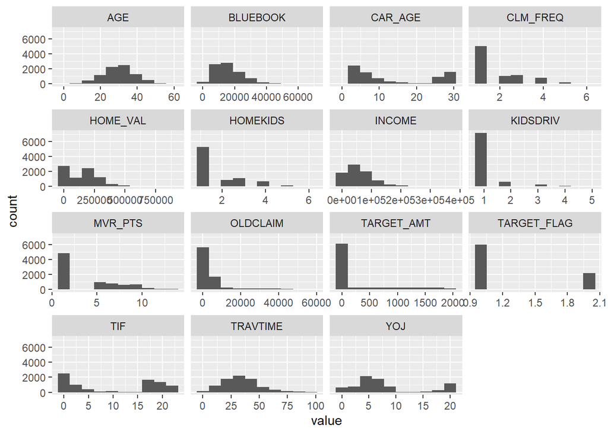

```r
ggplot(gather(ins_train_numeric), aes(value)) +
    geom_histogram(bins = 10) +
    facet_wrap(~key, scales = 'free_x')
```

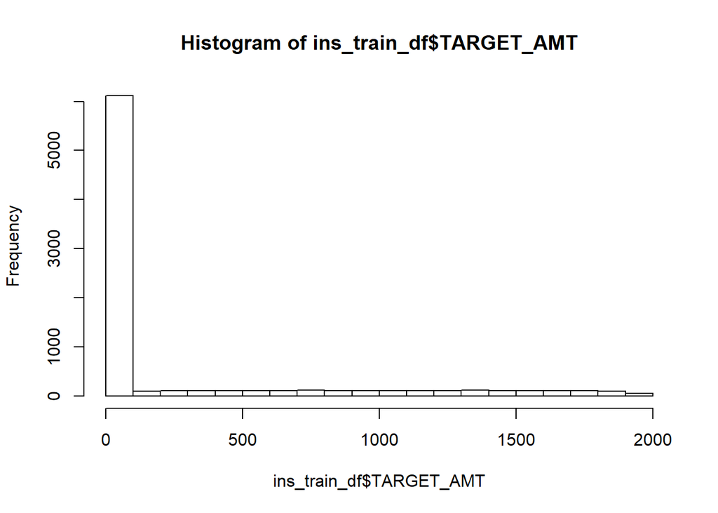

```r
#have a deeper look, potentially need to transform, huge variance
hist(ins_train_df$TARGET_AMT)
```

```r
summary(ins_train_df$TARGET_AMT)
```

```
##    Min. 1st Qu.  Median    Mean 3rd Qu.    Max.
##     1.0     1.0     1.0   258.7   111.0  1949.0
```

```r
var(ins_train_df$TARGET_AMT)
```

```
## [1] 266354.4
```

```r
var(log(ins_train_df$TARGET_AMT+1))
```

```
## [1] 7.013553
```

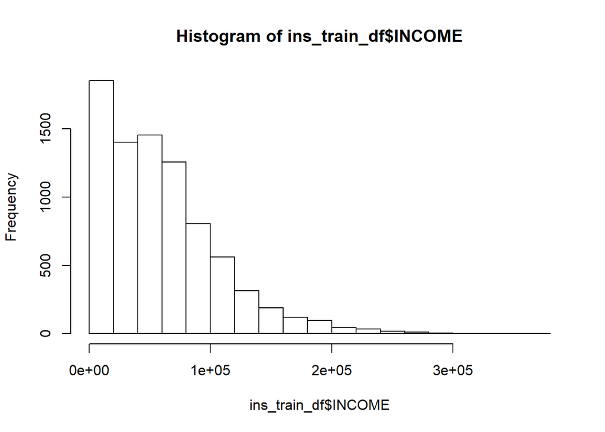

```r
#benefit of log transform,
#we added because there a lot of 0's in Target_AMT, we added 1

#log of 0 undefined, thats why 0, need to find a better transformation that handles zeros well

#have a deeper look, potentially need to transform, huge variance
hist(ins_train_df$INCOME)
```

```r
summary(ins_train_df$INCOME)
```

```
##    Min. 1st Qu.  Median    Mean 3rd Qu.    Max.
##       0   23157   51116   58523   83304  367030
```

```r
var(ins_train_df$INCOME)
```

```
## [1] 2337288545
```

```r
var(log(ins_train_df$INCOME+1))
```

```
## [1] 13.98386
```

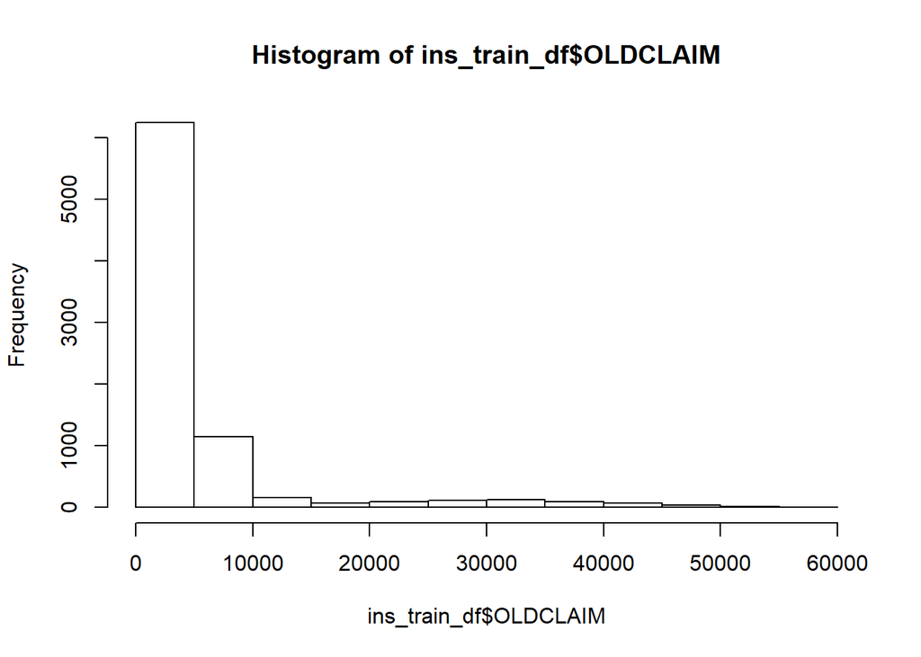

```r
#table(ins_train_df$INCOME)

#have a deeper look, potentially need to transform, huge variance (extremely compressed)
#important to note log0 is undefinded, in order to transform needed to change to 1
#age, yoj,car_age many misssing values
#we are focusing on the ones with missing values first

hist(ins_train_df$OLDCLAIM)
```

```r
summary(ins_train_df$OLDCLAIM)
```

```
##    Min. 1st Qu.  Median    Mean 3rd Qu.    Max.
##       0       0       0    4037    4636   57037
```

```r
var(ins_train_df$OLDCLAIM)
```

```
## [1] 77038171
```

```r
var(log(ins_train_df$OLDCLAIM+1))
```

```
## [1] 18.59325
```

```r
#table(ins_train_df$OLDCLAIM)

summary(ins_train_df)
```

```
##      INDEX       TARGET_FLAG      TARGET_AMT        KIDSDRIV
##  1      :   1   Min.   :1.000   Min.   :   1.0   Min.   :1.000
##  100    :   1   1st Qu.:1.000   1st Qu.:   1.0   1st Qu.:1.000
##  1000   :   1   Median :1.000   Median :   1.0   Median :1.000
##  10001  :   1   Mean   :1.264   Mean   : 258.7   Mean   :1.171
##  10002  :   1   3rd Qu.:2.000   3rd Qu.: 111.0   3rd Qu.:1.000
##  10004  :   1   Max.   :2.000   Max.   :1949.0   Max.   :5.000
##  (Other):8155
##       AGE           HOMEKIDS          YOJ             INCOME
##  Min.   : 1.00   Min.   :1.000   Min.   : 1.000   Min.   :     0
##  1st Qu.:24.00   1st Qu.:1.000   1st Qu.: 4.000   1st Qu.: 23157
##  Median :30.00   Median :1.000   Median : 6.000   Median : 51116
##  Mean   :29.79   Mean   :1.721   Mean   : 7.993   Mean   : 58523
##  3rd Qu.:36.00   3rd Qu.:2.000   3rd Qu.: 8.000   3rd Qu.: 83304
##  Max.   :60.00   Max.   :6.000   Max.   :21.000   Max.   :367030
##  NA's   :6                       NA's   :454
##   PARENT1           HOME_VAL       MSTATUS        SEX             EDUCATION
##  Mode :logical   Min.   :     0   Mode :logical   F:4375   <High School:1203
##  FALSE:7084      1st Qu.:     0   FALSE:3267      M:3786   High School :2330
##  TRUE :1077      Median :151957   TRUE :4894               Bachelors   :2242
##                  Mean   :146062                            Masters     :1658
##                  3rd Qu.:233352                            PhD         : 728
##                  Max.   :885282
##
##            JOB          TRAVTIME           CAR_USE        BLUEBOOK
##  Blue Collar :1825   Min.   : 1.00   Commercial:3029   Min.   : 1500
##  Clerical    :1271   1st Qu.:22.00   Private   :5132   1st Qu.: 9280
##  Professional:1117   Median :33.00                     Median :14440
##  Manager     : 988   Mean   :34.19                     Mean   :15710
##  Lawyer      : 835   3rd Qu.:44.00                     3rd Qu.:20850
##  Student     : 712   Max.   :97.00                     Max.   :69740
##  (Other)     :1413
##       TIF               CAR_TYPE     RED_CAR           OLDCLAIM
##  Min.   : 1.00   Minivan    :2145   Mode :logical   Min.   :    0
##  1st Qu.: 1.00   Panel Truck: 676   FALSE:5783      1st Qu.:    0
##  Median : 9.00   Pickup     :1389   TRUE :2378      Median :    0
##  Mean   :10.54   Sports Car : 907                   Mean   : 4037
##  3rd Qu.:20.00   SUV        :2294                   3rd Qu.: 4636
##  Max.   :23.00   Van        : 750                   Max.   :57037
##
##     CLM_FREQ      REVOKED           MVR_PTS         CAR_AGE
##  Min.   :1.000   Mode :logical   Min.   : 1.00   Min.   : 1.00
##  1st Qu.:1.000   FALSE:7161      1st Qu.: 1.00   1st Qu.: 3.00
##  Median :1.000   TRUE :1000      Median : 2.00   Median : 8.00
##  Mean   :1.799                   Mean   : 3.87   Mean   :13.35
##  3rd Qu.:3.000                   3rd Qu.: 7.00   3rd Qu.:27.00
##  Max.   :6.000                   Max.   :13.00   Max.   :30.00
##                                                  NA's   :510
##                URBANICITY
##  Highly Rural/ Rural:1669
##  Highly Urban/ Urban:6492
##
##
##
##
##
```

```r
# ggplot(gather(ins_train_numeric, cols, value), aes(x = value)) +
#        geom_histogram(binwidth = 20) + facet_grid(.~cols)


##correlation matrix
ins_train_numeric.rcorr = rcorr(as.matrix(ins_train_numeric))
ins_train_numeric.rcorr
```

```
##             TARGET_FLAG TARGET_AMT KIDSDRIV   AGE HOMEKIDS   YOJ INCOME
## TARGET_FLAG        1.00       0.83     0.10 -0.10     0.12 -0.02  -0.13
## TARGET_AMT         0.83       1.00     0.09 -0.09     0.10 -0.01  -0.11
## KIDSDRIV           0.10       0.09     1.00 -0.08     0.46 -0.02  -0.04
## AGE               -0.10      -0.09    -0.08  1.00    -0.45 -0.02   0.17
## HOMEKIDS           0.12       0.10     0.46 -0.45     1.00 -0.06  -0.15
## YOJ               -0.02      -0.01    -0.02 -0.02    -0.06  1.00   0.11
## INCOME            -0.13      -0.11    -0.04  0.17    -0.15  0.11   1.00
## HOME_VAL          -0.17      -0.14    -0.02  0.19    -0.10  0.05   0.50
## TRAVTIME           0.01       0.02     0.01  0.00     0.02  0.00  -0.03
## BLUEBOOK          -0.10      -0.09    -0.02  0.17    -0.11  0.06   0.41
## TIF               -0.03      -0.02    -0.02  0.00    -0.01  0.02  -0.02
## OLDCLAIM           0.14       0.11     0.02 -0.03     0.03 -0.01  -0.04
## CLM_FREQ           0.22       0.18     0.04 -0.02     0.03  0.01  -0.04
## MVR_PTS            0.20       0.18     0.06 -0.06     0.05 -0.01  -0.05
## CAR_AGE            0.00       0.00     0.00 -0.05     0.03  0.01  -0.06
##             HOME_VAL TRAVTIME BLUEBOOK   TIF OLDCLAIM CLM_FREQ MVR_PTS CAR_AGE
## TARGET_FLAG    -0.17     0.01    -0.10 -0.03     0.14     0.22    0.20    0.00
## TARGET_AMT     -0.14     0.02    -0.09 -0.02     0.11     0.18    0.18    0.00
## KIDSDRIV       -0.02     0.01    -0.02 -0.02     0.02     0.04    0.06    0.00
## AGE             0.19     0.00     0.17  0.00    -0.03    -0.02   -0.06   -0.05
## HOMEKIDS       -0.10     0.02    -0.11 -0.01     0.03     0.03    0.05    0.03
## YOJ             0.05     0.00     0.06  0.02    -0.01     0.01   -0.01    0.01
## INCOME          0.50    -0.03     0.41 -0.02    -0.04    -0.04   -0.05   -0.06
## HOME_VAL        1.00    -0.03     0.24  0.00    -0.07    -0.09   -0.07   -0.03
## TRAVTIME       -0.03     1.00    -0.03  0.00    -0.01     0.00    0.01    0.01
## BLUEBOOK        0.24    -0.03     1.00  0.00    -0.03    -0.04   -0.04   -0.01
## TIF             0.00     0.00     0.00  1.00     0.00     0.00    0.01   -0.02
## OLDCLAIM       -0.07    -0.01    -0.03  0.00     1.00     0.50    0.25    0.00
## CLM_FREQ       -0.09     0.00    -0.04  0.00     0.50     1.00    0.39   -0.01
## MVR_PTS        -0.07     0.01    -0.04  0.01     0.25     0.39    1.00    0.00
## CAR_AGE        -0.03     0.01    -0.01 -0.02     0.00    -0.01    0.00    1.00
##
## n
##             TARGET_FLAG TARGET_AMT KIDSDRIV  AGE HOMEKIDS  YOJ INCOME HOME_VAL
## TARGET_FLAG        8161       8161     8161 8155     8161 7707   8161     8161
## TARGET_AMT         8161       8161     8161 8155     8161 7707   8161     8161
## KIDSDRIV           8161       8161     8161 8155     8161 7707   8161     8161
## AGE                8155       8155     8155 8155     8155 7701   8155     8155
## HOMEKIDS           8161       8161     8161 8155     8161 7707   8161     8161
```

[output cut: 45 more lines]

```
## TARGET_FLAG 0.0000   0.2170   0.0000   0.0104 0.0000   0.0000   0.0000  0.9608
## TARGET_AMT  0.0000   0.1304   0.0000   0.0427 0.0000   0.0000   0.0000  0.9181
## KIDSDRIV    0.1648   0.2221   0.0516   0.0481 0.0653   0.0008   0.0000  0.8362
## AGE         0.0000   0.9851   0.0000   0.8874 0.0082   0.0293   0.0000  0.0000
## HOMEKIDS    0.0000   0.1232   0.0000   0.1828 0.0069   0.0080   0.0000  0.0132
## YOJ         0.0000   0.6641   0.0000   0.0852 0.5736   0.3926   0.5074  0.2111
## INCOME      0.0000   0.0025   0.0000   0.1368 0.0001   0.0001   0.0000  0.0000
## HOME_VAL             0.0061   0.0000   0.8711 0.0000   0.0000   0.0000  0.0141
## TRAVTIME    0.0061            0.0091   0.7966 0.5314   0.6738   0.2518  0.4242
## BLUEBOOK    0.0000   0.0091            0.7955 0.0077   0.0010   0.0009  0.2382
## TIF         0.8711   0.7966   0.7955          0.9587   0.7226   0.4064  0.0864
## OLDCLAIM    0.0000   0.5314   0.0077   0.9587          0.0000   0.0000  0.6964
## CLM_FREQ    0.0000   0.6738   0.0010   0.7226 0.0000            0.0000  0.3687
## MVR_PTS     0.0000   0.2518   0.0009   0.4064 0.0000   0.0000           0.7916
## CAR_AGE     0.0141   0.4242   0.2382   0.0864 0.6964   0.3687   0.7916
```

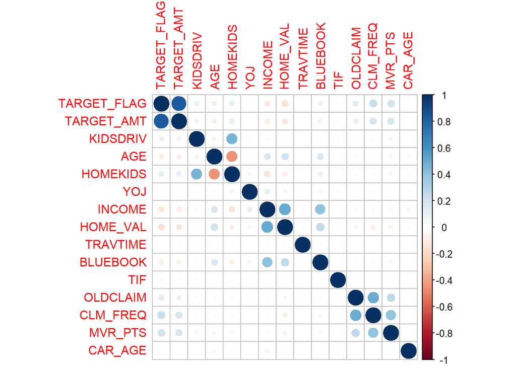

```r
#a lot of NA's for the three variables, Correlation take all values in the column and associate them

ins_train_numeric.cor = cor(ins_train_numeric, use = "complete.obs")
corrplot(ins_train_numeric.cor)
```

```r
#homekids looks like good group for imputing ages
#table(ins_train_df$HOMEKIDS)
#incoming needs to be clustered for imputing



#create five clusters of income
kmeans.re <- kmeans(ins_train_df$INCOME, centers = 5)
table(kmeans.re$cluster)
```

```
##
##    1    2    3    4    5
## 2529 2074  335 1078 2145
```

```r
ins_train_df$inc_clusters <- kmeans.re$cluster
#table(ins_train_df$INCOME)

#we are creating groups based on homekids, replace missing value
ins_train_df <- ins_train_df %>%
             group_by(HOMEKIDS) %>%
            mutate(AGE= ifelse(is.na(AGE), mean(AGE, na.rm=TRUE), AGE))


#we are creating groups based on car_age, replace missing value
ins_train_df <- ins_train_df %>%
             group_by(inc_clusters) %>%
            mutate(CAR_AGE= ifelse(is.na(CAR_AGE), mean(CAR_AGE, na.rm=TRUE), CAR_AGE))

#we are creating groups based on homekids, replace missing value
#no group value is highly correlated by YOJ
ins_train_df <- ins_train_df %>%
  mutate(YOJ= ifelse(is.na(YOJ), mean(YOJ, na.rm=TRUE), YOJ))

summary(ins_train_df)
```

```
##      INDEX       TARGET_FLAG      TARGET_AMT        KIDSDRIV
##  1      :   1   Min.   :1.000   Min.   :   1.0   Min.   :1.000
##  100    :   1   1st Qu.:1.000   1st Qu.:   1.0   1st Qu.:1.000
##  1000   :   1   Median :1.000   Median :   1.0   Median :1.000
##  10001  :   1   Mean   :1.264   Mean   : 258.7   Mean   :1.171
##  10002  :   1   3rd Qu.:2.000   3rd Qu.: 111.0   3rd Qu.:1.000
##  10004  :   1   Max.   :2.000   Max.   :1949.0   Max.   :5.000
##  (Other):8155
##       AGE           HOMEKIDS          YOJ             INCOME
##  Min.   : 1.00   Min.   :1.000   Min.   : 1.000   Min.   :     0
##  1st Qu.:24.00   1st Qu.:1.000   1st Qu.: 4.000   1st Qu.: 23157
##  Median :30.00   Median :1.000   Median : 6.000   Median : 51116
##  Mean   :29.78   Mean   :1.721   Mean   : 7.990   Mean   : 58523
##  3rd Qu.:36.00   3rd Qu.:2.000   3rd Qu.: 8.562   3rd Qu.: 83304
##  Max.   :60.00   Max.   :6.000   Max.   :21.000   Max.   :367030
##
##   PARENT1           HOME_VAL       MSTATUS        SEX             EDUCATION
##  Mode :logical   Min.   :     0   Mode :logical   F:4375   <High School:1203
##  FALSE:7084      1st Qu.:     0   FALSE:3267      M:3786   High School :2330
##  TRUE :1077      Median :151957   TRUE :4894               Bachelors   :2242
##                  Mean   :146062                            Masters     :1658
##                  3rd Qu.:233352                            PhD         : 728
##                  Max.   :885282
##
##            JOB          TRAVTIME           CAR_USE        BLUEBOOK
##  Blue Collar :1825   Min.   : 1.00   Commercial:3029   Min.   : 1500
##  Clerical    :1271   1st Qu.:22.00   Private   :5132   1st Qu.: 9280
##  Professional:1117   Median :33.00                     Median :14440
##  Manager     : 988   Mean   :34.19                     Mean   :15710
##  Lawyer      : 835   3rd Qu.:44.00                     3rd Qu.:20850
##  Student     : 712   Max.   :97.00                     Max.   :69740
##  (Other)     :1413
##       TIF               CAR_TYPE     RED_CAR           OLDCLAIM
##  Min.   : 1.00   Minivan    :2145   Mode :logical   Min.   :    0
##  1st Qu.: 1.00   Panel Truck: 676   FALSE:5783      1st Qu.:    0
##  Median : 9.00   Pickup     :1389   TRUE :2378      Median :    0
##  Mean   :10.54   Sports Car : 907                   Mean   : 4037
##  3rd Qu.:20.00   SUV        :2294                   3rd Qu.: 4636
##  Max.   :23.00   Van        : 750                   Max.   :57037
##
##     CLM_FREQ      REVOKED           MVR_PTS         CAR_AGE
##  Min.   :1.000   Mode :logical   Min.   : 1.00   Min.   : 1.00
##  1st Qu.:1.000   FALSE:7161      1st Qu.: 1.00   1st Qu.: 4.00
##  Median :1.000   TRUE :1000      Median : 2.00   Median : 9.00
##  Mean   :1.799                   Mean   : 3.87   Mean   :13.34
##  3rd Qu.:3.000                   3rd Qu.: 7.00   3rd Qu.:26.00
##  Max.   :6.000                   Max.   :13.00   Max.   :30.00
##
##                URBANICITY    inc_clusters
##  Highly Rural/ Rural:1669   Min.   :1.000
##  Highly Urban/ Urban:6492   1st Qu.:1.000
##                             Median :2.000
##                             Mean   :2.784
##                             3rd Qu.:5.000
##                             Max.   :5.000
##
```

```r
#correlations between variables we highly suspect

cor_inctarget <- cor.test(ins_train_df$INCOME, ins_train_df$TARGET_AMT)
cor_inctarget
```

```
##
##  Pearson's product-moment correlation
##
## data:  ins_train_df$INCOME and ins_train_df$TARGET_AMT
## t = -10.073, df = 8159, p-value < 2.2e-16
## alternative hypothesis: true correlation is not equal to 0
## 95 percent confidence interval:
##  -0.13220627 -0.08934616
## sample estimates:
##        cor
## -0.1108277
```

```r
cor_hovaltarget <- cor.test(ins_train_df$HOME_VAL, ins_train_df$TARGET_AMT)
cor_hovaltarget
```

```
##
##  Pearson's product-moment correlation
##
## data:  ins_train_df$HOME_VAL and ins_train_df$TARGET_AMT
## t = -12.457, df = 8159, p-value < 2.2e-16
## alternative hypothesis: true correlation is not equal to 0
## 95 percent confidence interval:
##  -0.1578447 -0.1152614
## sample estimates:
##        cor
## -0.1366162
```

```r
cor_cfreqtarget<- cor.test(ins_train_df$CLM_FREQ, ins_train_df$TARGET_AMT)
cor_cfreqtarget
```

```
##
##  Pearson's product-moment correlation
##
## data:  ins_train_df$CLM_FREQ and ins_train_df$TARGET_AMT
## t = 16.906, df = 8159, p-value < 2.2e-16
## alternative hypothesis: true correlation is not equal to 0
## 95 percent confidence interval:
##  0.1629217 0.2048466
## sample estimates:
##       cor
## 0.1839678
```

```r
cor_mptstarget<- cor.test(ins_train_df$MVR_PTS, ins_train_df$TARGET_AMT)
cor_mptstarget
```

```
##
##  Pearson's product-moment correlation
##
## data:  ins_train_df$MVR_PTS and ins_train_df$TARGET_AMT
## t = 16.156, df = 8159, p-value < 2.2e-16
## alternative hypothesis: true correlation is not equal to 0
## 95 percent confidence interval:
##  0.1549652 0.1970135
## sample estimates:
##       cor
## 0.1760697
```

```r
cor_travtarget<- cor.test(ins_train_df$TRAVTIME, ins_train_df$TARGET_AMT)
cor_travtarget
```

```
##
##  Pearson's product-moment correlation
##
## data:  ins_train_df$TRAVTIME and ins_train_df$TARGET_AMT
## t = 1.5127, df = 8159, p-value = 0.1304
## alternative hypothesis: true correlation is not equal to 0
## 95 percent confidence interval:
##  -0.004953605  0.038427074
## sample estimates:
##        cor
## 0.01674461
```

```r
#the weaker the correlation the higher the p value

#ttests
#most P values significantly low
t_inctarget <- t.test(ins_train_df$INCOME~ ins_train_df$TARGET_FLAG)
t_inctarget
```

```
##
##  Welch Two Sample t-test
##
## data:  ins_train_df$INCOME by ins_train_df$TARGET_FLAG
## t = 12.604, df = 4321.4, p-value < 2.2e-16
## alternative hypothesis: true difference in means is not equal to 0
## 95 percent confidence interval:
##  12008.56 16432.63
## sample estimates:
## mean in group 1 mean in group 2
##        62274.55        48053.96
```

```r
t_hovaltarget <- t.test(ins_train_df$HOME_VAL~ ins_train_df$TARGET_FLAG)
t_hovaltarget
```

```
##
##  Welch Two Sample t-test
##
## data:  ins_train_df$HOME_VAL by ins_train_df$TARGET_FLAG
## t = 16.56, df = 4222.1, p-value < 2.2e-16
## alternative hypothesis: true difference in means is not equal to 0
## 95 percent confidence interval:
##  44648.07 56639.42
## sample estimates:
## mean in group 1 mean in group 2
##        159422.8        108779.1
```

```r
t_cfreqtarget<- t.test(ins_train_df$CLM_FREQ~ ins_train_df$TARGET_FLAG)
t_cfreqtarget
```

```
##
##  Welch Two Sample t-test
##
## data:  ins_train_df$CLM_FREQ by ins_train_df$TARGET_FLAG
## t = -18.734, df = 3388.4, p-value < 2.2e-16
## alternative hypothesis: true difference in means is not equal to 0
## 95 percent confidence interval:
##  -0.6277464 -0.5087966
## sample estimates:
## mean in group 1 mean in group 2
##        1.648635        2.216907
```

```r
t_mptstarget<- t.test(ins_train_df$MVR_PTS~ ins_train_df$TARGET_FLAG)
t_mptstarget
```

```
##
##  Welch Two Sample t-test
##
## data:  ins_train_df$MVR_PTS by ins_train_df$TARGET_FLAG
## t = -16.882, df = 3333.9, p-value < 2.2e-16
## alternative hypothesis: true difference in means is not equal to 0
## 95 percent confidence interval:
##  -1.706330 -1.351222
## sample estimates:
## mean in group 1 mean in group 2
##        3.467044        4.995820
```

```r
t_travtarget<- t.test(ins_train_df$TRAVTIME~ ins_train_df$TARGET_FLAG)
t_travtarget
```

```
##
##  Welch Two Sample t-test
##
## data:  ins_train_df$TRAVTIME by ins_train_df$TARGET_FLAG
## t = -1.2703, df = 4009.6, p-value = 0.204
## alternative hypothesis: true difference in means is not equal to 0
## 95 percent confidence interval:
##  -1.3089192  0.2796336
## sample estimates:
## mean in group 1 mean in group 2
##        34.05526        34.56990
```

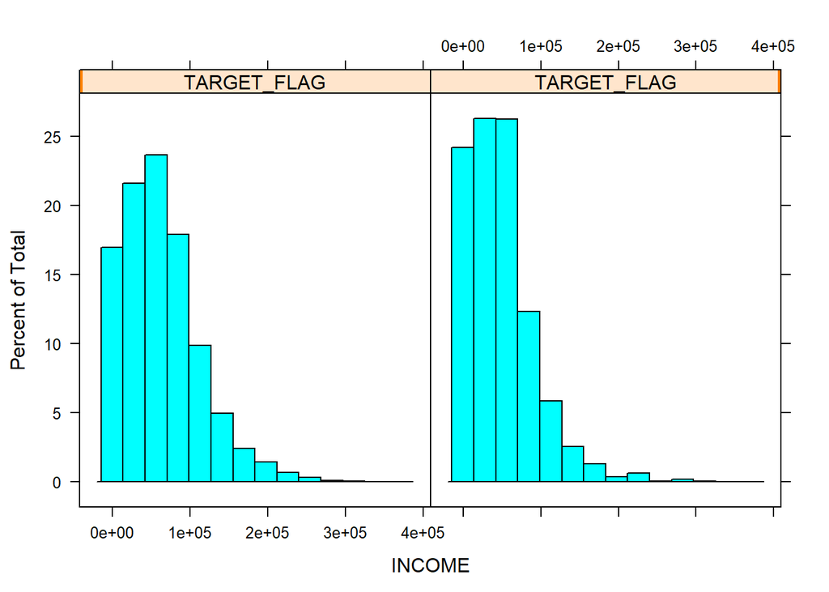

```r
#percentages is better because same scale for both graphs

histogram(~ INCOME | TARGET_FLAG, data = ins_train_df)
```

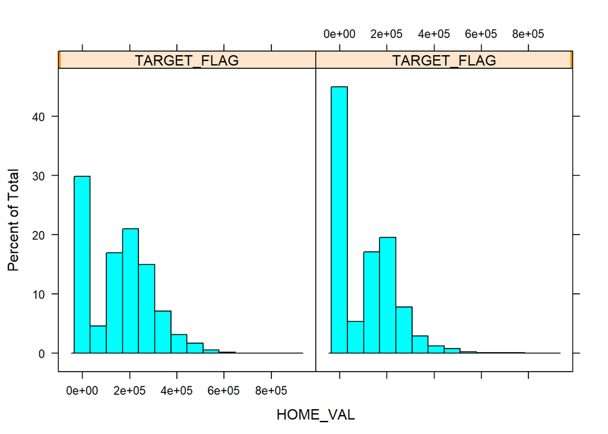

```r
histogram(~ HOME_VAL | TARGET_FLAG, data = ins_train_df)
```

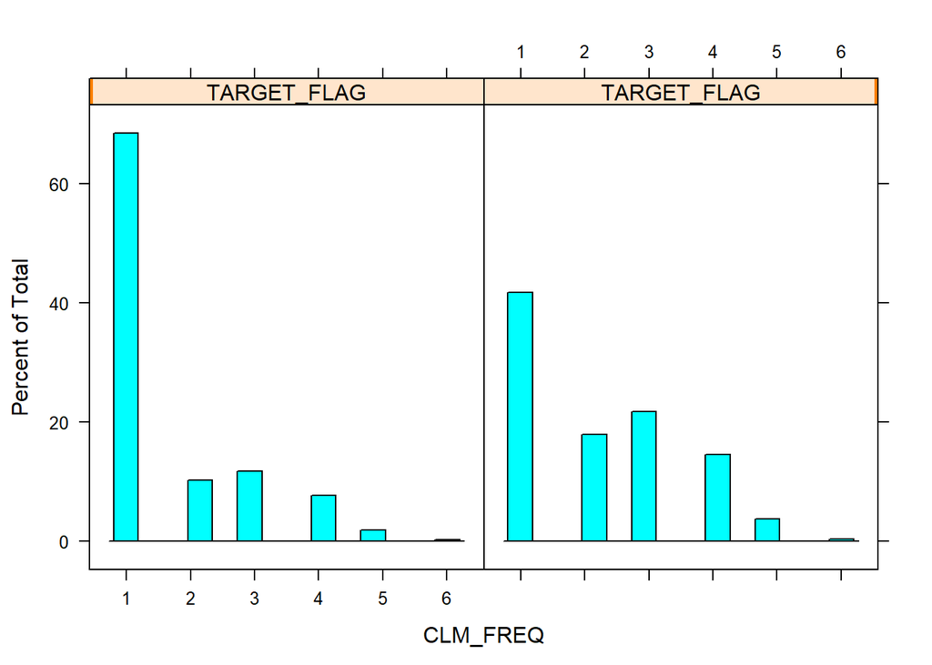

```r
histogram(~ CLM_FREQ | TARGET_FLAG, data = ins_train_df)
```

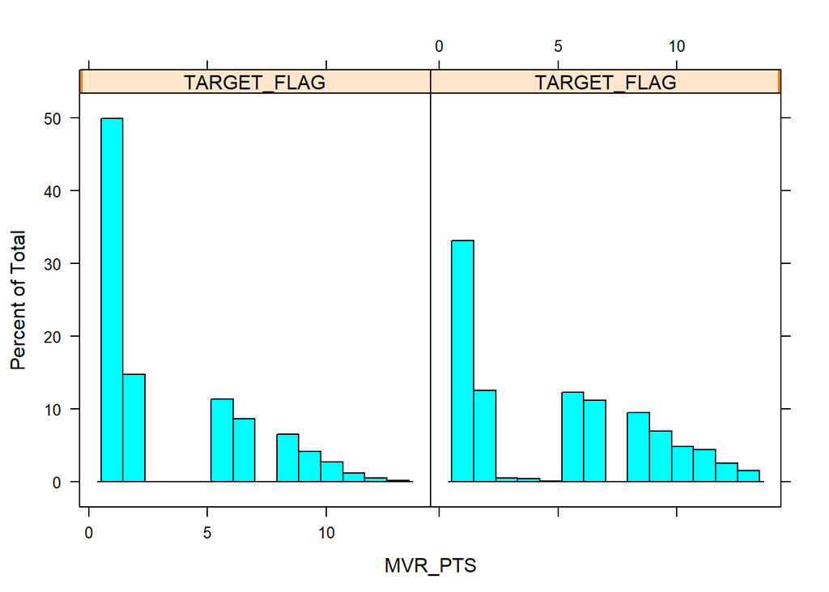

```r
histogram(~ MVR_PTS | TARGET_FLAG, data = ins_train_df)
```

```r
#checking the distribution, flag 0 means no car crashes, target 1 means car crashes, we are checking distribution of income between both
```

## 3. Build the Models

### Models predicting TARGET_AMT

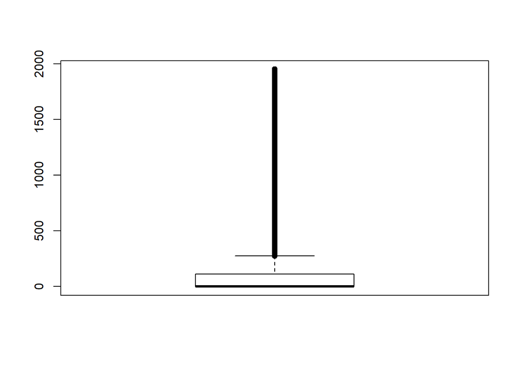

```r
#inspecting the TARGET_AMT variable
boxplot(ins_train_df$TARGET_AMT)
```

```r
summary(ins_train_df$TARGET_AMT)
```

```
##    Min. 1st Qu.  Median    Mean 3rd Qu.    Max.
##     1.0     1.0     1.0   258.7   111.0  1949.0
```

#### Model 1- All variables discussed above or literally ALL?

```r
#Building model using all features.

lm_ins_train_df <- lm(TARGET_AMT ~ KIDSDRIV + AGE + HOMEKIDS + YOJ + INCOME +
                    PARENT1 +HOME_VAL + MSTATUS + SEX + EDUCATION + JOB + TRAVTIME +
                    CAR_USE + BLUEBOOK + TIF + CAR_TYPE + RED_CAR + OLDCLAIM + CLM_FREQ +
                    REVOKED + MVR_PTS + CAR_AGE + URBANICITY
                    , data = ins_train_df)

summary(lm_ins_train_df)
```

```
##
## Call:
## lm(formula = TARGET_AMT ~ KIDSDRIV + AGE + HOMEKIDS + YOJ + INCOME +
##     PARENT1 + HOME_VAL + MSTATUS + SEX + EDUCATION + JOB + TRAVTIME +
##     CAR_USE + BLUEBOOK + TIF + CAR_TYPE + RED_CAR + OLDCLAIM +
##     CLM_FREQ + REVOKED + MVR_PTS + CAR_AGE + URBANICITY, data = ins_train_df)
##
## Residuals:
##     Min      1Q  Median      3Q     Max
## -869.32 -292.65 -129.89   65.36 2041.53
##
## Coefficients:
##                                 Estimate Std. Error t value Pr(>|t|)
## (Intercept)                   -8.367e+01  5.188e+01  -1.613 0.106794
## KIDSDRIV                       5.700e+01  1.183e+01   4.819 1.47e-06 ***
## AGE                           -8.393e-01  7.300e-01  -1.150 0.250333
## HOMEKIDS                       9.062e+00  6.710e+00   1.350 0.176894
## YOJ                           -1.245e-02  9.066e-01  -0.014 0.989043
## INCOME                        -3.924e-04  1.695e-04  -2.315 0.020646 *
## PARENT1TRUE                    5.200e+01  2.113e+01   2.462 0.013856 *
## HOME_VAL                      -7.728e-05  5.624e-05  -1.374 0.169474
## MSTATUSTRUE                   -8.583e+01  1.476e+01  -5.816 6.26e-09 ***
## SEXM                           2.217e+01  1.922e+01   1.154 0.248634
## EDUCATION.L                   -4.200e+01  2.646e+01  -1.587 0.112510
## EDUCATION.Q                    2.874e+01  1.656e+01   1.736 0.082638 .
## EDUCATION.C                    8.155e+00  1.445e+01   0.564 0.572492
## EDUCATION^4                   -2.750e+01  1.230e+01  -2.235 0.025445 *
## JOBBlue Collar                 9.060e+01  3.363e+01   2.694 0.007082 **
## JOBClerical                    9.972e+01  3.563e+01   2.799 0.005138 **
## JOBDoctor                     -1.832e+01  4.275e+01  -0.429 0.668288
## JOBHome Maker                  9.445e+01  3.724e+01   2.536 0.011229 *
## JOBLawyer                      2.383e+01  3.091e+01   0.771 0.440603
## JOBManager                    -4.408e+01  3.016e+01  -1.462 0.143889
## JOBProfessional                5.046e+01  3.228e+01   1.563 0.118016
## JOBStudent                     1.123e+02  3.849e+01   2.918 0.003528 **
## TRAVTIME                       8.887e-01  3.202e-01   2.775 0.005534 **
## CAR_USEPrivate                -1.220e+02  1.719e+01  -7.096 1.39e-12 ***
## BLUEBOOK                      -3.102e-03  9.014e-04  -3.441 0.000583 ***
## TIF                           -1.327e+00  5.970e-01  -2.222 0.026304 *
## CAR_TYPEPanel Truck            6.086e+01  2.909e+01   2.092 0.036485 *
## CAR_TYPEPickup                 6.494e+01  1.785e+01   3.638 0.000277 ***
## CAR_TYPESports Car             1.366e+02  2.277e+01   6.000 2.06e-09 ***
## CAR_TYPESUV                    1.005e+02  1.876e+01   5.357 8.69e-08 ***
## CAR_TYPEVan                    7.287e+01  2.230e+01   3.268 0.001088 **
## RED_CARTRUE                   -1.971e+01  1.559e+01  -1.264 0.206204
## OLDCLAIM                      -3.227e-03  7.771e-04  -4.153 3.32e-05 ***
## CLM_FREQ                       3.808e+01  5.745e+00   6.628 3.62e-11 ***
## REVOKEDTRUE                    1.496e+02  1.814e+01   8.246  < 2e-16 ***
## MVR_PTS                        1.330e+01  1.693e+00   7.857 4.45e-15 ***
## CAR_AGE                       -5.409e-01  5.134e-01  -1.054 0.292112
## URBANICITYHighly Urban/ Urban  2.878e+02  1.450e+01  19.857  < 2e-16 ***
## ---
## Signif. codes:  0 '***' 0.001 '**' 0.01 '*' 0.05 '.' 0.1 ' ' 1
##
## Residual standard error: 475.3 on 8123 degrees of freedom
## Multiple R-squared:  0.1557, Adjusted R-squared:  0.1518
## F-statistic: 40.48 on 37 and 8123 DF,  p-value: < 2.2e-16
```

#### Model 2- Selectively chosen variables

```r
#Building model Selectively chosen features.

lms_ins_train_df <- lm(TARGET_AMT ~ KIDSDRIV +   MSTATUS + CAR_USE + BLUEBOOK +  CAR_TYPE
                      + OLDCLAIM + CLM_FREQ + REVOKED + MVR_PTS + URBANICITY
                    , data = ins_train_df)

summary(lms_ins_train_df)
```

```
##
## Call:
## lm(formula = TARGET_AMT ~ KIDSDRIV + MSTATUS + CAR_USE + BLUEBOOK +
##     CAR_TYPE + OLDCLAIM + CLM_FREQ + REVOKED + MVR_PTS + URBANICITY,
##     data = ins_train_df)
##
## Residuals:
##     Min      1Q  Median      3Q     Max
## -875.61 -290.38 -150.68   56.25 1967.78
##
## Coefficients:
##                                 Estimate Std. Error t value Pr(>|t|)
## (Intercept)                    4.815e+01  2.686e+01   1.793  0.07300 .
## KIDSDRIV                       8.148e+01  1.049e+01   7.764 9.19e-15 ***
## MSTATUSTRUE                   -1.055e+02  1.094e+01  -9.645  < 2e-16 ***
## CAR_USEPrivate                -1.547e+02  1.321e+01 -11.718  < 2e-16 ***
## BLUEBOOK                      -6.527e-03  7.802e-04  -8.367  < 2e-16 ***
## CAR_TYPEPanel Truck            3.514e+01  2.582e+01   1.361  0.17359
## CAR_TYPEPickup                 5.699e+01  1.760e+01   3.237  0.00121 **
## CAR_TYPESports Car             1.362e+02  1.945e+01   7.003 2.71e-12 ***
## CAR_TYPESUV                    1.015e+02  1.482e+01   6.849 7.98e-12 ***
## CAR_TYPEVan                    5.491e+01  2.144e+01   2.561  0.01045 *
## OLDCLAIM                      -3.127e-03  7.871e-04  -3.973 7.17e-05 ***
## CLM_FREQ                       4.219e+01  5.807e+00   7.267 4.03e-13 ***
## REVOKEDTRUE                    1.584e+02  1.836e+01   8.627  < 2e-16 ***
## MVR_PTS                        1.481e+01  1.710e+00   8.660  < 2e-16 ***
## URBANICITYHighly Urban/ Urban  2.225e+02  1.385e+01  16.066  < 2e-16 ***
## ---
## Signif. codes:  0 '***' 0.001 '**' 0.01 '*' 0.05 '.' 0.1 ' ' 1
##
## Residual standard error: 482 on 8146 degrees of freedom
## Multiple R-squared:  0.1292, Adjusted R-squared:  0.1278
## F-statistic: 86.37 on 14 and 8146 DF,  p-value: < 2.2e-16
```

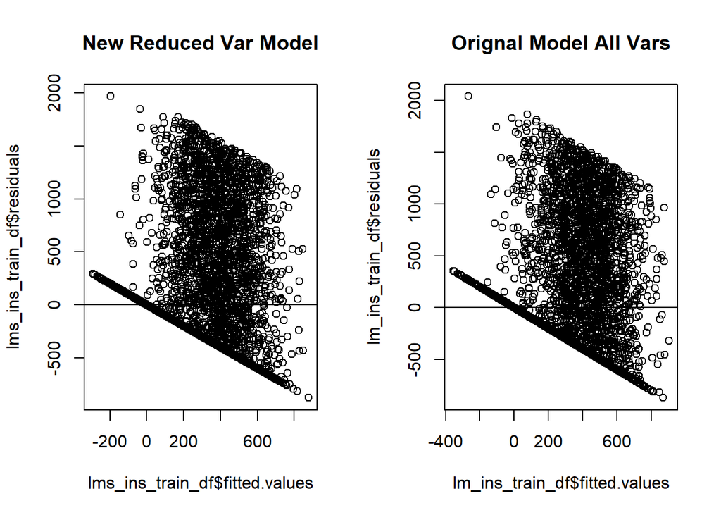

```r
par(mfrow=c(1,2))
plot(lms_ins_train_df$residuals ~ lms_ins_train_df$fitted.values, main="New Reduced Var Model")
abline(h = 0)
plot(lm_ins_train_df$residuals ~ lm_ins_train_df$fitted.values, main="Orignal Model All Vars")
abline(h = 0)
```

## 4. Select Models